# Week5-2_Text Analytics

Kyu Cho

July 4, 2015

```r
library(caTools)
library(tm)
library(SnowballC)
library(rpart)
library(rpart.plot)
library(randomForest)
library(ROCR)

setwd("D:/Google Drive/College/4-The Analytics Edge/data5")

# stringsAsFactors false for working on a text analytics to read in properly.
emails = read.csv("energy_bids.csv", stringsAsFactors = FALSE)
summary(emails)
```

```
##     email             responsive
##  Length:855         Min.   :0.0000
##  Class :character   1st Qu.:0.0000
##  Mode  :character   Median :0.0000
##                     Mean   :0.1626
##                     3rd Qu.:0.0000
##                     Max.   :1.0000
```

```r
str(emails)
```

```
## 'data.frame':    855 obs. of  2 variables:
##  $ email     : chr  "North America's integrated electricity market requires cooperation on environmental policies Commission for Environmental Coope"| __truncated__ "FYI -----Original Message----- From: \t\"Ginny Feliciano\" <gfeliciano@earthlink.net>@ENRON [mailto:IMCEANOTES-+22Ginny+20Felic"| _…
##  $ responsive: int  0 1 0 1 0 0 1 0 0 0 ...
```

# Understading the data

```r
# Convert the horizontal orientation into vertical orientation to make it easy to read.
head(strwrap(emails$email[1]))
```

```
## [1] "North America's integrated electricity market requires cooperation"
## [2] "on environmental policies Commission for Environmental Cooperation"
## [3] "releases working paper on North America's electricity market"
## [4] "Montreal, 27 November 2001 -- The North American Commission for"
## [5] "Environmental Cooperation (CEC) is releasing a working paper"
## [6] "highlighting the trend towards increasing trade, competition and"
```

```r
emails$responsive[1]
```

```
## [1] 0
```

```r
head(strwrap(emails$email[2]))
```

```
## [1] "FYI -----Original Message----- From: \"Ginny Feliciano\""
## [2] "<gfeliciano@earthlink.net>@ENRON"
## [3] "[mailto:IMCEANOTES-+22Ginny+20Feliciano+22+20+3Cgfeliciano+40earthlink+2Enet+3E+40ENRON@ENRON.com]"
## [4] "Sent: Thursday, June 28, 2001 3:40 PM To: Silvia Woodard; Paul"
## [5] "Runci; Katrin Thomas; John A. Riggs; Kurt E. Yeager; Gregg Ward;"
## [6] "Philip K. Verleger; Admiral Richard H. Truly; Susan Tomasky;"
```

```r
emails$responsive[2]
```

```
## [1] 1
```

```r
# Responsive emails
table(emails$responsive)
```

```
##
##   0   1
## 716 139
```

Relatively small proportion of emails responsive to the query.

# Cleaning the data

```r
emails$responsive = as.factor(emails$responsive)

# Create corpus
corpus = Corpus(VectorSource(emails$email))
corpus = tm_map(corpus, tolower)
corpus = tm_map(corpus, PlainTextDocument)
corpus = tm_map(corpus, removePunctuation)
corpus = tm_map(corpus, removeWords, stopwords("english"))
corpus = tm_map(corpus, stemDocument)
```

Now the emails in this corpus are ready for our machine learning algorithms.

# Removing sparesTerms

We have too many indipendent variables which means it requires heavy computational. Let’s remove some terms that don’t appear very often.

```r
# Create matrix
dtm = DocumentTermMatrix(corpus)

# Look at matrix
inspect(dtm[800:805,505:515])
```

```
## <<DocumentTermMatrix (documents: 6, terms: 11)>>
## Non-/sparse entries: 2/64
## Sparsity           : 97%
## Maximal term length: 8
## Weighting          : term frequency (tf)
##
##               Terms
## Docs           05092000 05092001 0510 051004 05102001 0511 051108 05112000
##   character(0)        0        0    0      0        0    0      0        0
##   character(0)        0        0    0      0        0    0      0        0
##   character(0)        0        0    0      0        0    0      0        0
##   character(0)        0        0    0      0        0    0      0        0
##   character(0)        0        1    0      0        1    0      0        0
##   character(0)        0        0    0      0        0    0      0        0
##               Terms
## Docs           05112001 051199 0512
##   character(0)        0      0    0
##   character(0)        0      0    0
##   character(0)        0      0    0
##   character(0)        0      0    0
##   character(0)        0      0    0
##   character(0)        0      0    0
```

```r
# Check for sparsity
findFreqTerms(dtm, lowfreq=800)
```

```
## [1] "email"   "enron"   "gas"     "market"  "power"   "price"   "subject"
## [8] "will"
```

```r
# Remove rest and keep the terms that appear in 3% in the document or more.
dtm = removeSparseTerms(dtm, 0.97)
dtm
```

```
## <<DocumentTermMatrix (documents: 855, terms: 788)>>
## Non-/sparse entries: 51612/622128
## Sparsity           : 92%
## Maximal term length: 19
## Weighting          : term frequency (tf)
```

```r
# Converting into dataframe
labeledTerms = as.data.frame(as.matrix(dtm))

# Add in the outcome variable
labeledTerms$responsive = emails$responsive
```

# Build model

## split dataset

```r
set.seed(144)
spl = sample.split(labeledTerms$responsive, 0.7)
train = subset(labeledTerms, spl == TRUE)
test = subset(labeledTerms, spl == FALSE)
```

# Build CART model

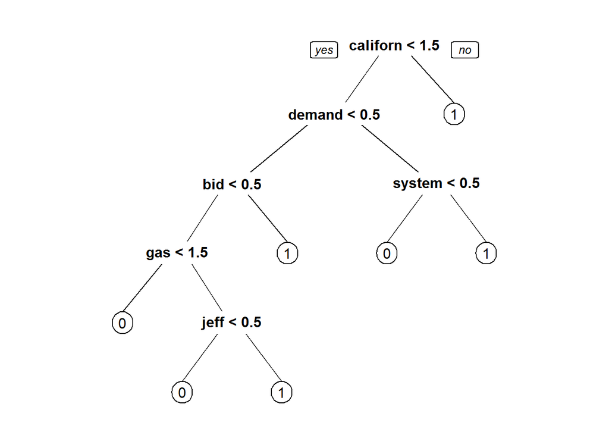

```r
# Build a CART model
emailCART = rpart(responsive~., data=train, method="class")
prp(emailCART)
```

It’s somewhat unsurprising that California shows up, because we know that Enron had a heavy involvement in the California energy markets.

# Evaluation

```r
# Make predictions on the test set
pred = predict(emailCART, newdata=test)
pred[1:10,]
```

```
##                        0          1
## character(0)   0.2156863 0.78431373
## character(0).1 0.9557522 0.04424779
## character(0).2 0.9557522 0.04424779
## character(0).3 0.8125000 0.18750000
## character(0).4 0.4000000 0.60000000
## character(0).5 0.9557522 0.04424779
## character(0).6 0.9557522 0.04424779
## character(0).7 0.9557522 0.04424779
## character(0).8 0.1250000 0.87500000
## character(0).9 0.1250000 0.87500000
```

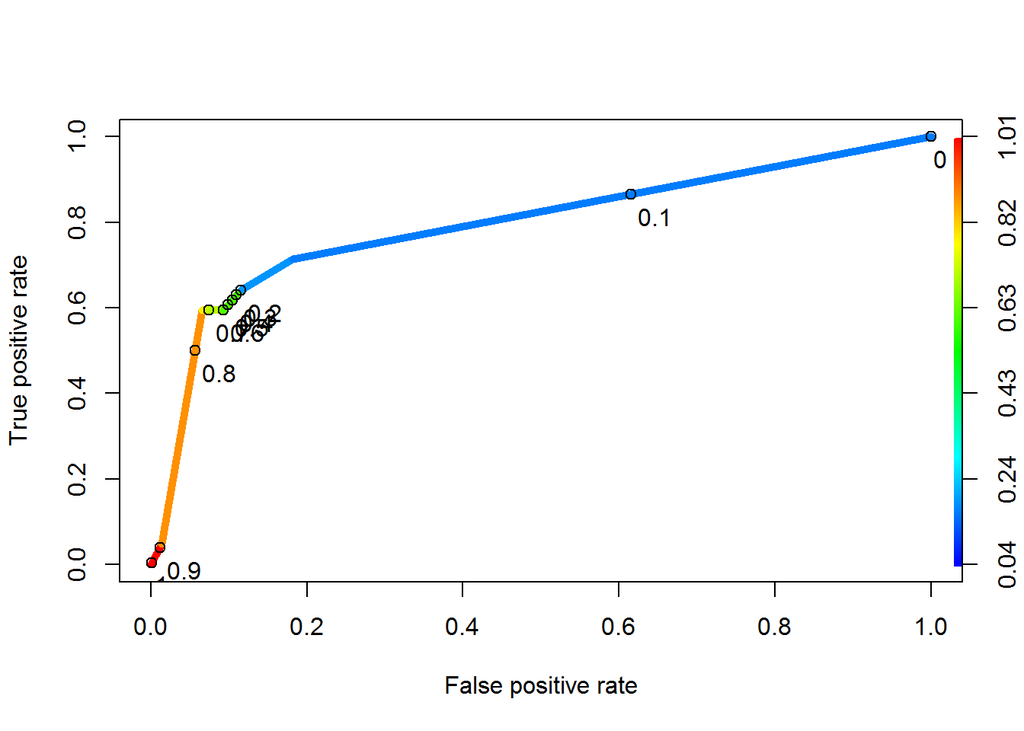

```r
# Since we are looking for the value 1 which is the responsive, extract second col.
pred.prob = pred[,2]

# Another method
pred2 = predict(emailCART, newdata=test, type="class")

# ROC curve
predROCR = prediction(pred.prob, test$responsive)
perfROCR = performance(predROCR, "tpr", "fpr")
plot(perfROCR, colorize=TRUE, print.cutoffs.at=seq(0,1,by=0.1), text.adj=c(-0.2,1.7), lwd=5)

# Another method
predROCR2 = prediction(pred[,2], test$responsive)
perfROCR2 = performance(predROCR2, "tpr", "fpr")
plot(perfROCR2, colorize=TRUE, print.cutoffs.at=seq(0,1,by=0.1), text.adj=c(-0.2,1.7), lwd=5)
```

```r
# Compute accuracy
table(test$responsive, pred.prob >= 0.2)
```

```
##
##     FALSE TRUE
##   0   195   20
##   1    17   25
```

```r
table(test$responsive, pred2)
```

```
##    pred2
##       0   1
##   0 195  20
##   1  17  25
```

```r
(195+25)/(195+25+17+20)
```

```
## [1] 0.8560311
```

```r
# Baseline model accuracy
table(test$responsive)
```

```
##
##   0   1
## 215  42
```

```r
215/(215+42)
```

```
## [1] 0.8365759
```

The place where a true positive rate of 70%, meaning that we’re getting about 70% of all the responsive documents, and a false positive rate of about 20%, meaning that we’re making mistakes and accidentally identifying as responsive. Now, since, typically, the vast majority of documents are non-responsive, operating at this cutoff would result, perhaps, in a large decrease in the amount of manual effort needed in the eDiscovery process. And we can see from the blue color of the plot at this particular location that we’re looking at a threshold around maybe 0.2 or so, significantly lower than 50%, which is definitely what we would expect since we favor false positives to false negatives.

```r
# Compute AUC
performance(predROCR, "auc")@y.values
```

```
## [[1]]
## [1] 0.7936323
```

We can see that we have an AUC in the test set of 79.4%, which means that our model can differentiate between a randomly selected responsive and non-responsive document about 80% of the time.